# AQI Analysis

#### Figure 6

We see from this barplot the count of Good and Moderate classifications by population density.

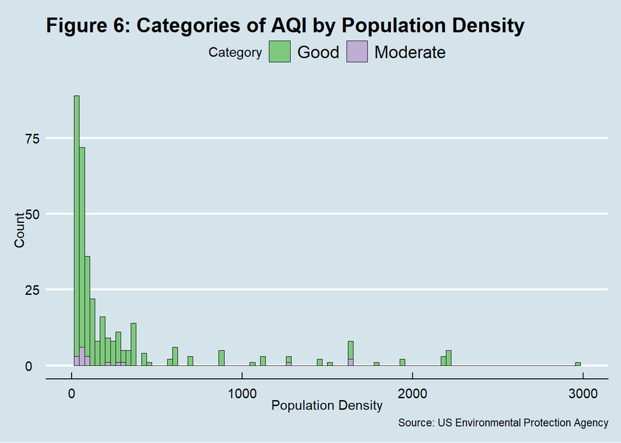

```r
dfsamp <- sample_frac(df, 0.01)
dfsamp %>%  ggplot(., aes(CountyPopDensity_perSqMile)) + scale_fill_brewer(palette = "Accent") +

 geom_histogram(aes(fill=Category),
                   bins=100,
                   col="black",
                   size=.1) +   # change number of bins
  xlim(c(0, 3000)) +
  labs(title="Figure 6: Categories of AQI by Population Density",
       caption = "Source: US Environmental Protection Agency",
       x = "Population Density",
       y = "Count") +
   theme_economist()
```

## Summary

The purpose of this analysis was to explore how AQI was affected by various regional variables such as population density, percentage of poverty, and county area size. Based on our findings it is reasonable to conclude the the quality of air in urban centers is lower than the air quality in rural areas. I think this finding is unsurprising when considering the increases industrial and human activity within these areas.

## Bibliography

Cairo, Alberto. “Alberto Cairo - How Charts Lie: Getting Smarter About Visual Information.” Youtube.com, WIT, 22 Mar. 2019, www.youtube.com/watch?v=Low28hx4wyk&t=353s&ab_channel=WIT.